# Eighty20 Business Insights Analyst Challenge

Channon Perry

2022-09-28

## Question 1: The birthday question

Attached is a list of a particular company’s clients’ birthdays (Q1_birthday_challenge.txt). There is something very interesting in the data. What is it? How do you think this happened?

### Answer 1: Birthdays with repeated digits in them are more common than expected

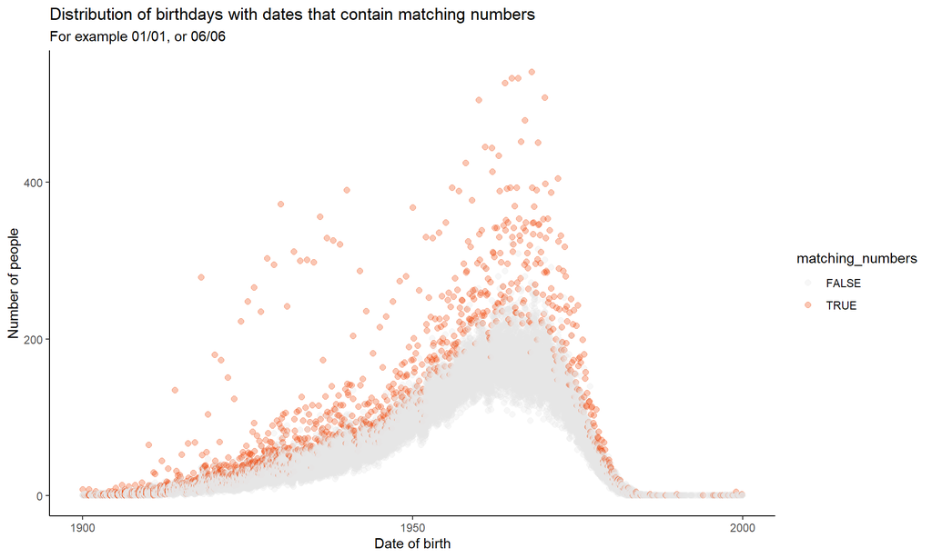

Orange points represent dates that contain matching numbers across the month and day, day and year, or month and year (for example, 01/01/1968, 06/11/1906, or 01/12/12), while grey dates are all unique. Clients were more likely to provide a birthday with repeated digits than the even distribution of birthdays expected in a year. This may be due to a few speculated reasons.

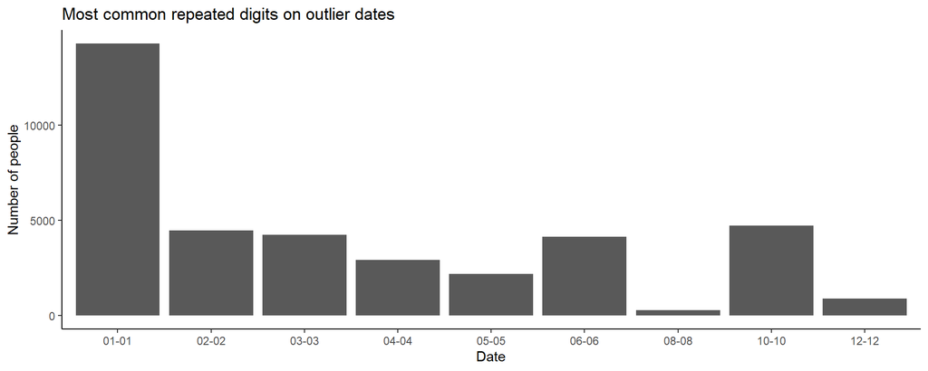

- Fake dates: People coming up with ‘random’ dates in order to quickly fill in a form may use repeating digits because it’s easier to make up.
- Formatting incomplete data: If the raw data was coerced into a date format, but was incomplete, data could have been automatically filled in with ones. For example, a birthdate of only ‘March 1968’ could be coerced to ‘01/03/1968’. The graph above shows that the most common repeated digits were 01/01.
- Cultural norms: In some places, like Korea, birthdays are celebrated on the New Year as opposed to birth dates.

**Click here to see more of my working out**

#### Year, month, and day distribion

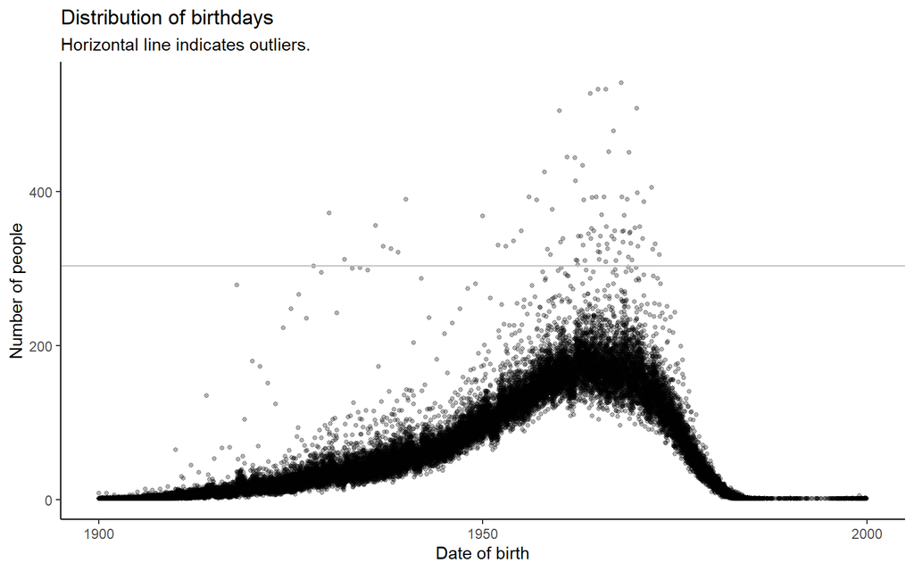

Considering how evenly the birthdays are distributed independently by day of the month, month of the year, and birth year shows the variable creating the left-tailed distribution was birth-years, because birth-days and birth-months appeared to be relatively evenly distributed.

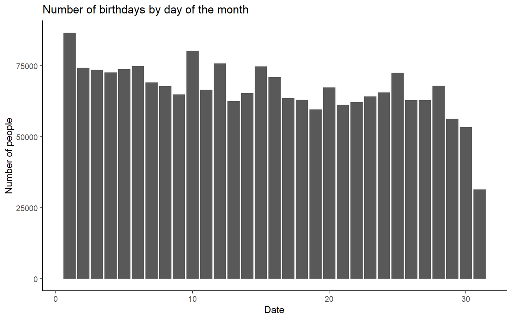

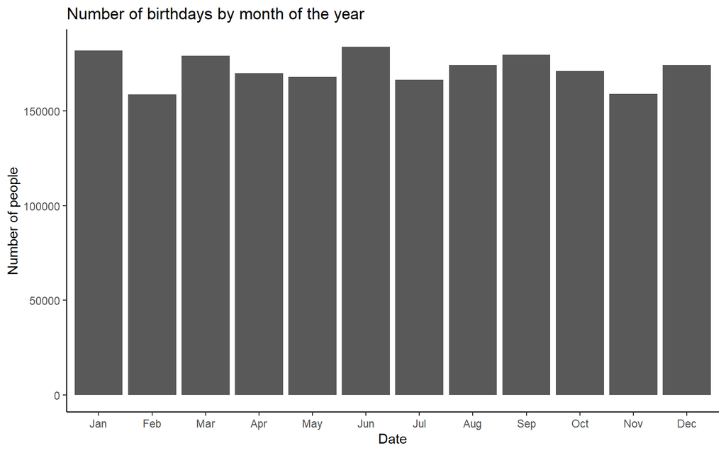

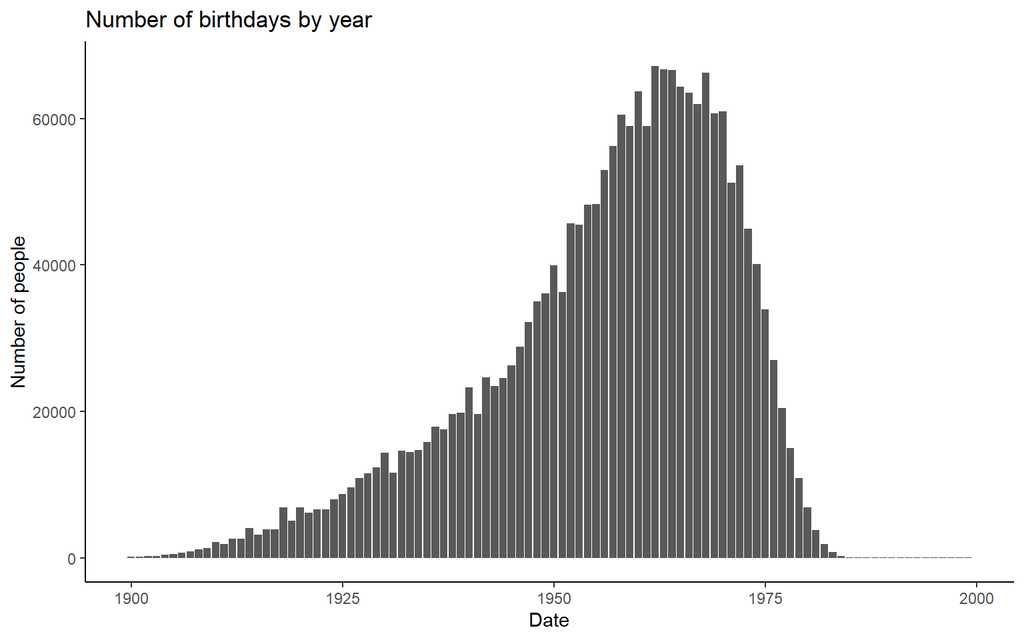

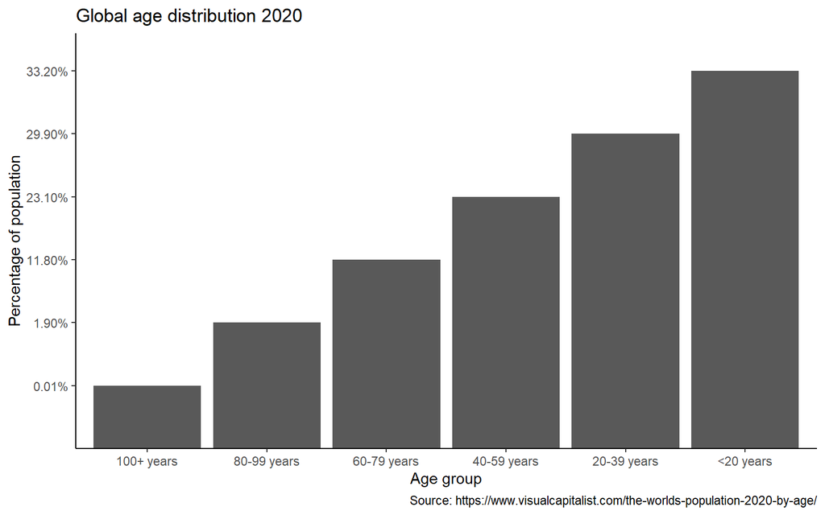

#### Day-month distribution

This suggests nothing stands out as unusual about the distribution of birthdays when considering the data longitudinally, and looking to patterns in the month and day may be more insightful.

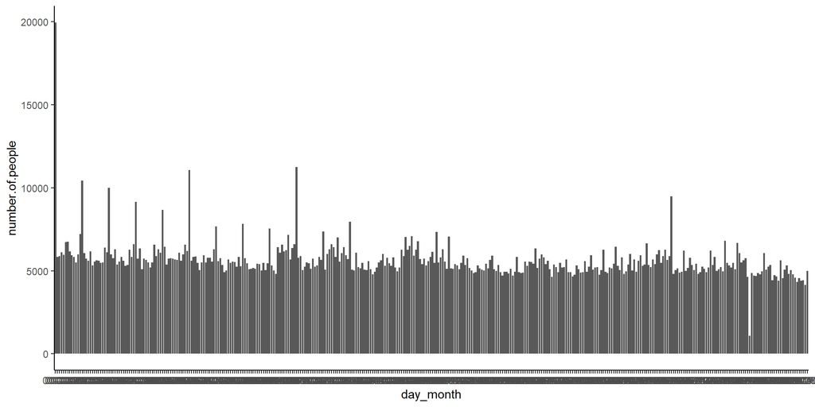

Here it is clearly visable that there are particular dates in the year that have much higher than expected frequencies.

When examining these days a clear pattern emerges with dates with digits that repeat each other like 01/01, 02/02, 10/10, appearing far more frequently than expected.

```
##    day_month number.of.people
## 1      01-01              541
## 2      01-01              533
## 3      01-01              533
## 4      01-01              527
## 5      01-01              508
## 6      01-01              505
## 7      01-01              479
## 8      06-06              452
## 9      01-01              451
## 10     01-01              445
## 11     01-01              444
## 12     01-01              434
## 13     01-01              425
## 14     02-02              414
## 15     01-01              405
## 16     02-02              398
## 17     01-01              393
## 18     10-10              393
## 19     10-10              393
## 20     02-02              393
```

## Question 2:

### Answer 2: